# TEAM MEMBERS DETAILS

1. Sai Kumar Patnaik (19CSE001)
2. Richa Thakur (19CSE025)
3. Niwesh Kumar Suman (19CSE026)
4. Susri Arpita Jena (19CSE177)
5. Priya Dash (19CSE295)
6. Sandhyarani Panda (19CSE299)
7. Shaista Naaz (19CSE348)
8. Simran kumari (19CSE356)

# STOCK PRICE PREDICTION

Stock Price Prediction using machine learning is the act of trying to determine the future value of a company stock or other financial instrument traded on an exchange. The entire idea of predicting stock prices is to gain significant profits. Predicting how the stock market will perform is a hard task to do. There are other factors involved in the prediction, such as physical and psychological factors, rational and irrational behavior, and so on. All these factors combine to make share prices dynamic and volatile. This makes it very difficult to predict stock prices with high accuracy.The successful prediction of a stock's future price could yield significant profit.

**Importance of Stock Market**

- Stock markets help companies to raise capital.
- It helps generate personal wealth.
- Stock markets serve as an indicator of the state of the economy.
- It is a widely used source for people to invest money in companies with high growth potential.

## IMPORTING LIBRARIES

As we all know, the first step is to import the libraries required to preprocess Apple stock data and the other libraries required for constructing and visualizing the model outputs. We’ll be using the libraries like numpy, pandas, matplotlib, seaborn, sklearn etc.. for this Prediction.

```python
import warnings
warnings.filterwarnings("ignore")

import pandas as pd
import numpy as np
import matplotlib.pyplot as plt
import matplotlib
matplotlib.rcParams['axes.labelsize']=18
matplotlib.rcParams['xtick.labelsize']=13
matplotlib.rcParams['ytick.labelsize']=13
matplotlib.rcParams['text.color']='#6A0DAD'


import seaborn as sns
import plotly.express as px

from sklearn.model_selection import train_test_split

from sklearn.metrics import precision_score, recall_score, f1_score, classification_report, accuracy_score
from sklearn.linear_model import LogisticRegression

from sklearn.linear_model import LinearRegression
from sklearn.metrics import mean_squared_error,r2_score,mean_absolute_error,mean_squared_log_error

from sklearn.tree import DecisionTreeRegressor

from sklearn.ensemble import RandomForestRegressor

import math
```

## READING DATA

```python
stock=pd.read_csv("AAPL.csv")
stock.head(10)
```

|  | Date | Open | High | Low | Close | Adj Close | Volume |
| --- | --- | --- | --- | --- | --- | --- | --- |
| 0 | 2014-09-29 | 100.589996 | 100.690002 | 98.040001 | 99.620003 | 93.514290 | 142718700 |
| 1 | 2014-10-06 | 99.949997 | 102.379997 | 98.309998 | 100.730003 | 94.556244 | 280258200 |
| 2 | 2014-10-13 | 101.330002 | 101.779999 | 95.180000 | 97.669998 | 91.683792 | 358539800 |
| 3 | 2014-10-20 | 98.320000 | 105.489998 | 98.220001 | 105.220001 | 98.771042 | 358532900 |
| 4 | 2014-10-27 | 104.849998 | 108.040001 | 104.699997 | 108.000000 | 101.380676 | 220230600 |
| 5 | 2014-11-03 | 108.220001 | 110.300003 | 107.720001 | 109.010002 | 102.328766 | 199952900 |
| 6 | 2014-11-10 | 109.019997 | 114.190002 | 108.400002 | 114.180000 | 107.646675 | 205166700 |
| 7 | 2014-11-17 | 114.269997 | 117.570000 | 113.300003 | 116.470001 | 109.805626 | 233414700 |
| 8 | 2014-11-24 | 116.849998 | 119.750000 | 116.620003 | 118.930000 | 112.124863 | 181873900 |
| 9 | 2014-12-01 | 118.809998 | 119.250000 | 111.269997 | 115.000000 | 108.419746 | 266589700 |

## CHECKING DATA INFORMATION

In this step, firstly we will print the structure of the dataset.

```python
print("Dataframe Shape: ", stock.shape)
```

```
Dataframe Shape:  (184, 7)
```

## Check for Null Values

Here we check for null values in the data frame to ensure that there are none. The existence of null values in the dataset causes issues during training since they function as outliers, creating a wide variance in the training process.

```python
stock.info()
```

```
<class 'pandas.core.frame.DataFrame'>
RangeIndex: 184 entries, 0 to 183
Data columns (total 7 columns):
 #   Column     Non-Null Count  Dtype
---  ------     --------------  -----
 0   Date       184 non-null    object
 1   Open       184 non-null    float64
 2   High       184 non-null    float64
 3   Low        184 non-null    float64
 4   Close      184 non-null    float64
 5   Adj Close  184 non-null    float64
 6   Volume     184 non-null    int64
dtypes: float64(5), int64(1), object(1)
memory usage: 10.2+ KB
```

```python
stock.isnull().sum()
```

```
Date         0
Open         0
High         0
Low          0
Close        0
Adj Close    0
Volume       0
dtype: int64
```

## DATA VISUALIZATION

The profit or loss calculation is usually determined by the closing price of a stock for the day, hence we will consider the closing price as the target variable. Let’s plot the target variable to understand how it’s shaping up in our data:

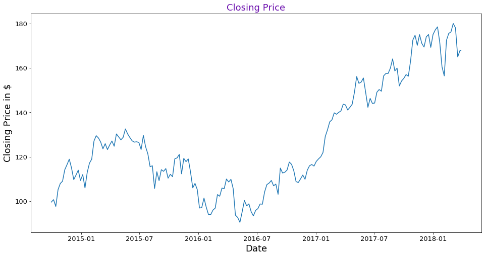

```python
stock['Date'] = pd.to_datetime(stock.Date,format='%Y-%m-%d')
stock.index = stock['Date']

plt.figure(figsize=(16,8))
plt.title("Closing Price",fontsize=18)
plt.plot(stock['Date'],stock['Close'])
plt.xlabel('Date',fontsize=18)
plt.ylabel('Closing Price in $',fontsize=18)
plt.show()
```

## FEATURE SELECTION

```python
cr=stock.corr()
cr
```

|  | Open | High | Low | Close | Adj Close | Volume |
| --- | --- | --- | --- | --- | --- | --- |
| Open | 1.000000 | 0.994001 | 0.993811 | 0.985060 | 0.983420 | -0.361986 |
| High | 0.994001 | 1.000000 | 0.992590 | 0.994716 | 0.992721 | -0.331615 |
| Low | 0.993811 | 0.992590 | 1.000000 | 0.993287 | 0.992043 | -0.415929 |
| Close | 0.985060 | 0.994716 | 0.993287 | 1.000000 | 0.997784 | -0.369616 |
| Adj Close | 0.983420 | 0.992721 | 0.992043 | 0.997784 | 1.000000 | -0.395737 |
| Volume | -0.361986 | -0.331615 | -0.415929 | -0.369616 | -0.395737 | 1.000000 |

```python
col=cr['Close'][:-1].index.tolist()
val=cr['Close'][:-1].tolist()
```

```python
finfet=[]
finval=[]
for i in range(len(col)):
    if val[i]>0.1:
        finfet.append(col[i])
        finval.append(val[i])
print(finfet)
print(finval)
```

```
['Open', 'High', 'Low', 'Close', 'Adj Close']
[0.9850599291761599, 0.9947155690257855, 0.9932874927728366, 1.0, 0.9977836909070336]
```

### CREATING PREDICTOR X AND TARGET Y

We will now split the data into train and validation sets to check the performance of the model.

```python
stock1=stock.copy()
stock1=stock1.reset_index(drop=True)
X=stock1.drop(['Date','Close'],axis=1)
y = stock1['Close'] # => Y-> Y_train, Y_test
```

### SPLITTING THE DATA

```python
X_train, X_test, y_train, y_test = train_test_split(X,y, test_size=0.2, random_state=0)
```

```python
X_train.head()
```

|  | Open | High | Low | Adj Close | Volume |
| --- | --- | --- | --- | --- | --- |
| 8 | 116.849998 | 119.750000 | 116.620003 | 112.124863 | 181873900 |
| 45 | 116.529999 | 119.989998 | 109.629997 | 110.713608 | 344717200 |
| 86 | 95.870003 | 100.730003 | 95.669998 | 97.331093 | 203888300 |
| 44 | 121.500000 | 122.570000 | 112.099998 | 109.796532 | 385000600 |
| 116 | 115.800003 | 117.500000 | 115.589996 | 114.210243 | 113254700 |

## Taking Classifiers in a List

```python
clf=[LinearRegression(),DecisionTreeRegressor(criterion='mse'),RandomForestRegressor(criterion='mse',n_estimators=64)]
```

```python
names=["Linear Regression","Decision Tree","Random Forest"]
```

## Validating the best model

```python
r2=[]
mse=[]
for i in range(len(clf)):
    model=clf[i]
    print(model)
    model.fit(X,y)
    clfpred=model.predict(X_test)
    r2.append(round(r2_score(y_test,clfpred),2)*100)
    mse.append(mean_squared_error(y_test,clfpred))
```

```
LinearRegression(copy_X=True, fit_intercept=True, n_jobs=None, normalize=False)
DecisionTreeRegressor(ccp_alpha=0.0, criterion='mse', max_depth=None,
                      max_features=None, max_leaf_nodes=None,
                      min_impurity_decrease=0.0, min_impurity_split=None,
                      min_samples_leaf=1, min_samples_split=2,
                      min_weight_fraction_leaf=0.0, presort='deprecated',
                      random_state=None, splitter='best')
RandomForestRegressor(bootstrap=True, ccp_alpha=0.0, criterion='mse',
                      max_depth=None, max_features='auto', max_leaf_nodes=None,
                      max_samples=None, min_impurity_decrease=0.0,
                      min_impurity_split=None, min_samples_leaf=1,
                      min_samples_split=2, min_weight_fraction_leaf=0.0,
                      n_estimators=64, n_jobs=None, oob_score=False,
                      random_state=None, verbose=0, warm_start=False)
```

## Finding R2 Score and Mean Square Error of the Classifiers taken in the list

```python
clfdf=pd.DataFrame({
    "Classifier":names,
    "R2":r2,
    "Mean Square Error":mse,
})
print(clfdf)
```

```
          Classifier     R2  Mean Square Error
0  Linear Regression  100.0           1.036067
1      Decision Tree  100.0           0.000000
2      Random Forest  100.0           0.193110
```

```python
for i in clfdf.columns[1:]:
    clfdf=clfdf.sort_values(by=i,ascending=False)
    fig=px.bar(clfdf,x="Classifier",y=i,color="Classifier",text=i,title="Comparison of {}".format(i),height=400,width=650)
    fig.show()
```

[interactive chart not shown]

```python
y_train.head(10)
```

```
8      118.930000
45     115.959999
86     100.349998
44     115.519997
116    116.519997
55     119.080002
24     125.900002
30     128.949997
98     109.360001
130    143.660004
Name: Close, dtype: float64
```

```python
X_test.iloc[:3]
```

|  | Open | High | Low | Adj Close | Volume |
| --- | --- | --- | --- | --- | --- |
| 139 | 153.419998 | 155.449997 | 152.220001 | 153.660797 | 88752900 |
| 106 | 115.019997 | 118.690002 | 114.720001 | 114.709305 | 208708400 |
| 7 | 114.269997 | 117.570000 | 113.300003 | 109.805626 | 233414700 |

```python
y_test.iloc[:3]
```

```
139    155.449997
106    117.629997
7      116.470001
Name: Close, dtype: float64
```

```python
tstcol=X_test.columns.tolist()
vals=[]
for i in tstcol:
    vals.append(eval(input("Enter {}: ".format(i))))
```

```
Enter Open: 114
Enter High: 117
Enter Low: 113
Enter Adj Close: 109
Enter Volume: 233414700
```

```python
vals1=[vals]
vals1
```

```
[[114, 117, 113, 109, 233414700]]
```

```python
clf[1].predict(vals1)[0]
```

```
114.709999
```

```python
regressor = DecisionTreeRegressor(criterion='mse')
regressor.fit(X_train,y_train)
```

```
DecisionTreeRegressor(ccp_alpha=0.0, criterion='mse', max_depth=None,
                      max_features=None, max_leaf_nodes=None,
                      min_impurity_decrease=0.0, min_impurity_split=None,
                      min_samples_leaf=1, min_samples_split=2,
                      min_weight_fraction_leaf=0.0, presort='deprecated',
                      random_state=None, splitter='best')
```

```python
y_pred = regressor.predict(X_test)
result = pd.DataFrame({'Actual':y_test,'Predicted':y_pred})
result.head(30)
```

|  | Actual | Predicted |
| --- | --- | --- |
| 139 | 155.449997 | 155.300003 |
| 106 | 117.629997 | 119.300003 |
| 7 | 116.470001 | 112.709999 |
| 107 | 116.599998 | 115.970001 |
| 60 | 117.809998 | 120.000000 |
| 97 | 108.180000 | 107.730003 |
| 61 | 119.029999 | 119.300003 |
| 166 | 169.369995 | 169.229996 |
| 33 | 132.539993 | 130.279999 |
| 170 | 175.000000 | 175.009995 |
| 163 | 170.149994 | 171.050003 |
| 71 | 93.989998 | 92.720001 |
| 5 | 109.010002 | 105.680000 |
| 113 | 109.900002 | 112.120003 |
| 151 | 159.860001 | 156.990005 |
| 146 | 150.270004 | 149.500000 |
| 18 | 118.930000 | 119.080002 |
| 66 | 96.959999 | 96.040001 |
| 150 | 157.500000 | 158.630005 |
| 74 | 103.010002 | 105.220001 |
| 167 | 173.970001 | 174.669998 |
| 160 | 163.050003 | 156.990005 |
| 56 | 119.500000 | 119.300003 |
| 174 | 160.500000 | 164.940002 |
| 156 | 154.119995 | 156.100006 |
| 4 | 108.000000 | 105.919998 |
| 54 | 111.040001 | 109.730003 |
| 131 | 143.339996 | 146.279999 |
| 118 | 117.910004 | 115.970001 |
| 123 | 132.119995 | 130.279999 |

```python
graph = result.head(20)
```

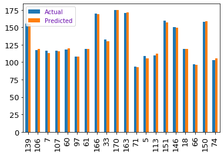

```python
graph.plot(kind='bar')
```